# Efficient Sequential Testing with Evidence Ratios

Ladislas Nalborczyk

2017-10-09

## Theoretical background

*This brief introduction is greatly inspired by a paper of Burnham & Anderson (2004): “Multimodel Inference, Understanding AIC and BIC in Model Selection”.*

Akaike’s approach allowed model selection to be firmly based on a fundamental theory and allowed further theoretical work. When $K$ is large relative to sample size n (which includes when $n$ is small, for any $K$), there is a small-sample (second-order bias correction) version of the AIC, called AICc:

$$AIC_c = AIC+\dfrac{2K(K+1)}{n-K-1}$$

knowing that:

$$AIC = -2log(\mathcal{L}(\hat{\theta}))+2K$$

where $-2log(\mathcal{L}(\hat{\theta}))$ is known as the *deviance* of a model (see Sugiura 1978; Hurvich and Tsai 1989, 1995). AICc should be used unless $n/K$ > about 40 for the model with the largest value of $K$.

The individual AICc values are not interpretable as they contain arbitrary constants and are much affected by sample size. Here it is imperative to rescale AICc to $\Delta_{AICc}=AICc_{i}-AICc_{min}$ where $AICc_{min}$ is the minimum of the $R$ different $AICc_{i}$ values (i.e., the minimum is at $i = min$). This transformation forces the best model to have $\Delta=0$, while the rest of the models have positive values.

The simple transformation $exp(−\Delta_i/2)$, for $i = 1, 2, ..., R$, provides the likelihood of the model (Akaike, 1981) given the data: $\mathcal{L}(g_i|data)$. This is a likelihood function over the model set in the sense that $\mathcal{L}(\theta|data, g_i)$ is the likelihood over the parameter space (for model $g_i$) of the parameter $\theta$, given the data ($x$) and the model ($g_i$).

It is convenient to normalize the model likelihoods such that they sum to 1 and treat them as probabilities; hence, we use

$$w_{i}=\dfrac{exp(-\Delta_{i}/2)}{\sum_{r=1}^{R}exp(-\Delta_{r}/2)}.$$

The $w_i$, called Akaike weights, are useful as the “weight of evidence” in favor of model $g_i(·|\theta)$ as being the actual Kullback-Leibler best model in the set. The ratios $w_i/w_j$ are identical to the original likelihood ratios, $\mathcal{L}(g_i|data)/\mathcal{L}(g_j|data)$, and so they are invariant to the model set, but the $w_i$ values depend on the full model set because they sum to 1.

Evidence can be judged by the relative likelihood of model pairs as $\mathcal{L}(g_i|x)/\mathcal{L}(g_j|x)$ or, equivalently, the ratio of Akaike weights $w_i/w_j$. Such ratios are called **evidence ratios** and represend the evidence about fitted models as to which is better in a Kullback-Leibler information sense.

## Installation

The `ESTER` package is not on CRAN yet, but you can install the development version from Github:

```r
if(!require(devtools)){install.packages("devtools")}
devtools::install_github("lnalborczyk/ESTER")
```

## Different questions

1. **Simulation**. Given an expected effect size and sample size, what ER evolution should I reasonnably expect ?
2. **Observed data**. When to stop recruiting participants ?

## 1. Simulation

This first function runs a simulated study in which we compare two independant groups, for various effect size and sample size. The `nmin` argument serves to specify from which participant we want to start doing sequential testing (usually we recommand to avoid `nmin` < 20).

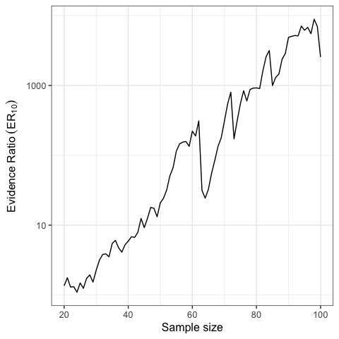

```r
library(ESTER)
ER <- simER(cohensd = 0.6, nmin = 20, n = 100, plot = TRUE)
```

We also can study the distribution of evidence ratios for `nsims` simulations runned with the previous function using `distER`.

```r
ER <- distER(cohensd = 0.6, nmin = 20, n = 100, nsims = 100)
```

[figure not shown]

## 2. Observed data

On the other hand (and perhaps more interestingly), `ESTER` can be used to do sequential testing on your own data. You can study the evolution of sequentials ERs using the `seqER` function.

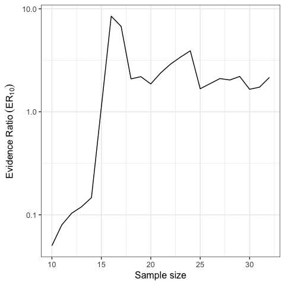

```r
data(mtcars)
mod1 <- lm(mpg ~ cyl, mtcars)
mod2 <- lm(mpg ~ cyl + disp, mtcars)
plot(seqER(mod1, mod2, nmin = 10) )
```

In addition, `seqERboot` allows you to study the behavior of sequential ERs computed on your own data, along with sequential ERs computed on bootstrapped samples from your data.

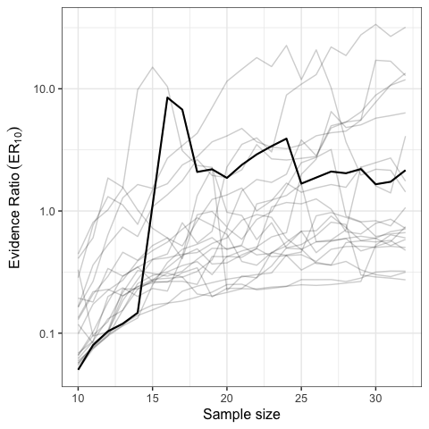

```r
plot(seqERboot(mod1, mod2, nmin = 10, order_nb = 20, replace = TRUE) )
```

Under the hood, `ESTER` uses the `AICcmodavg` package (available on [CRAN](https://cran.r-project.org/web/packages/AICcmodavg/index.html); Mazerolle, 2016) to compute AICc and Akaike Weights.